# Statistics some problems (and solution)

# LSP: Benefits/Problems/Tools

- Reliability: Easier to find/fix bugs. The results produced will not change when recomputed (in theory at least).
- Efficiency: Reuse allows to avoid duplication of effort (Payoff in the long run.)
- Transparency: increased citation rate, broader impact, improved institutional memory
- Institutional memory is a collective set of facts, concepts, experiences and know-how held by a group of people.
- Flexibility: When you don’t ‘point-and-click’ you gain many new analytic options.

Problems of LSP: Many incl. costs and learning curve

Tools:

- Document formatting language: LaTeX (not recommended) or Markdown (or many others, ie. orgmode). LaTeX is a word processor/a document markup language. Markdown: lightweight document markup language based on email text formatting. Easy to write, read and publish as-is.
- Program language: R

# Github for the uninitiated

The basic idea is that instead of manually registering changes one has made to data, documents etc, one can use software to help him manage the whole process. Such software is called **Version Control Systems** or VCS

VCS not only manages content, registering each modification of it, but control access to the content as well. Thus many individuals can work on common project (compare this to common scenario of mailing spreadsheets to each other–highly inefficient at least)

There are highly reliable and publicly available VCS services and GitHub is the most popular of them.

GitHub is owned by Microsoft (do not use if you boycott MS :-))

I use GitHub as an educational tool: to distribute learning content to my students and to store content they produce for me (ie projects)

The free GitHub account is public. It is OK for me. If it is not OK for you, you can buy a license for commercial account or do not use GitHub.

# Resources

- [Rstudio](https://www.rstudio.com/resources/cheatsheets/)
- [Making Data Meaningful](https://www.unece.org/stats/documents/writing/)
- [bookdown: Authoring Books and Technical Documents with R Markdown](https://bookdown.org/yihui/bookdown/)
- [Polish Main Statistical Office](https://stat.gov.pl/)
- Bank Danych Lokalnych (Local Data Bank)https://bdl.stat.gov.pl/BDL/start)
- [Eurostat (European Union Statistical Office)](https://ec.europa.eu/eurostat/data/database)
- [My github repository](https://github.com/hrpunio))
- [Tourism](http://appsso.eurostat.ec.europa.eu/nui/submitViewTableAction.do)
- [Coffee production/consumption](https://www.kaggle.com/sbajew/icos-crop-data)
- [GISCO](https://ec.europa.eu/eurostat/web/gisco/overview)
- [NUTS downolad page](https://ec.europa.eu/eurostat/web/gisco/geodata/reference-data/administrative-units-statistical-units/nuts)
- [TERYT download page](http://eteryt.stat.gov.pl/eTeryt/rejestr_teryt/udostepnianie_danych/formy_i_zasady_udostepniania/formy_i_zasady_udostepniania.aspx?contrast=default)
- [World Borders Dataset](http://thematicmapping.org/downloads/world_borders.php)
- [QGIS tutorials](https://www.qgistutorials.com/en/docs/)
- [gis.stackexchange.com](https://gis.stackexchange.com/)

# Questions?

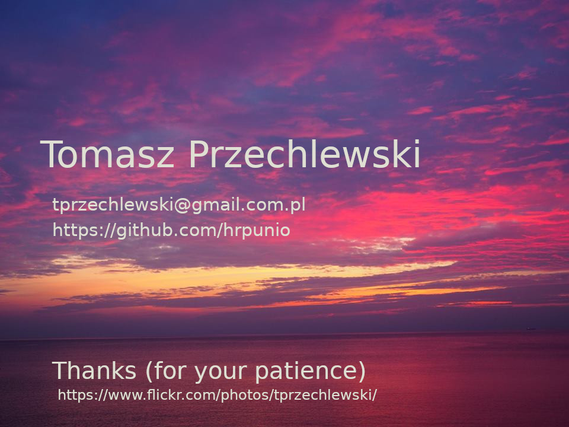